# yumCoffee

This is a project I decided to take on after I finished my first statistical computing class. I was on a coding high then, and I’m 99% confident that the high is still going.

In this project, I collected my own tasting profile for coffee and decided to plot my patterns. It’s funny because as I did this plotting project and as I continue to collect more data, I can see some obvious patterns in my data that I actually didn’t notice of myself.

# My Coffee Taste Profile

I recorded all of my preferences for all coffees that I have tried. Right now, I’m still getting through two whole bean bags of Peet’s coffee, so I won’t be able to add in new data for a while.

I put my ratings in `coffee_list.csv`, which you can access [here](https://github.com/palautatan/yumCoffee/blob/master/datasets/coffee_list.csv). Here’s a random sample of what is in `coffee_list.csv`.

```
##                Brand                    Name       Roast           Store
## 12      Mr. Espresso Sumatra Classic Lintong Medium-Dark Never Too Latte
## 14            Peet's        Major Dickason's        Dark          Costco
## 19      Philz Coffee     Tantalizing Turkish        Dark    Philz Coffee
## 17   Never Too Latte     Coconut Mocha Latte     Special Never Too Latte
## 7  San Francisco Bay     French Roast OneCup      French          Costco
##    Rating
## 12   3.00
## 14   2.75
## 19   4.25
## 17   3.00
## 7    4.00
```

I also have some pretty “savage” notes of how I felt about the cofee.

```
## [1] The flavor here was a bit too fruity for me, although I would drink it from time to time if it was presented to me
## [2] I don't think I really like this. It's tangy.
## [3] There's something really complicated about this flavor that I like. My mom hates it though.
## [4] I liked the pistachio one way better.
## [5] Flavor is blended with something, pretty damn yummy, kinda creamy without creamer
## 19 Levels: A lot better than I expected; no awful acidic aftertaste, stronger flavor than stated ...
```

# Visualizing Coffee Preferences

Here’s a plot of the coffees I have had according to roast. In this plot “Special” means that the coffee was not black.

### Favorite Roast

Let’s look at my favorite roasts! In the following plot, you can see some data points that represent where I got the coffee from, my rating, and the roast of the coffee.

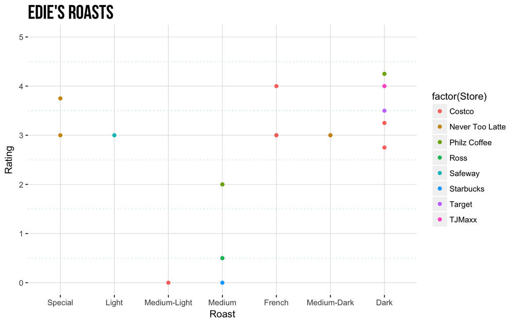

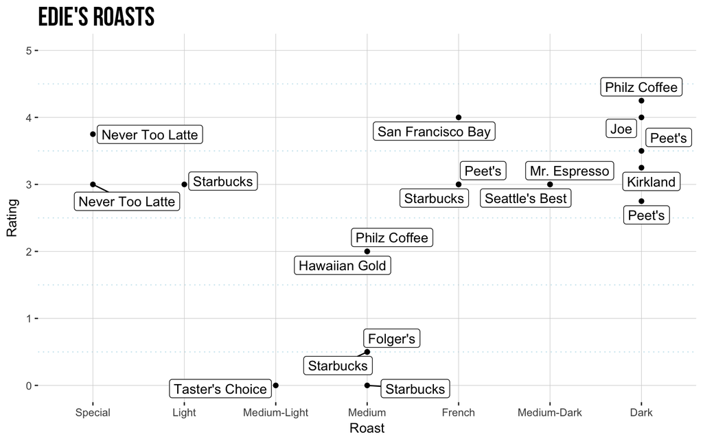

I know that many statisticians hate pie charts, but you can at least admit they’re pretty.

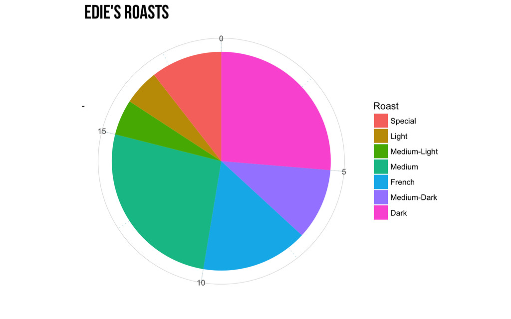

The following calculation tells me what my favorite roasts are according to my taste profile. I don’t agree with it though because I know that I really like French Roast. I just haven’t had enough French Roasts or had more decent Dark Roasts.

```
## This taster's favorite drinks have been from:
##  Dark.
```

### Favorite Store

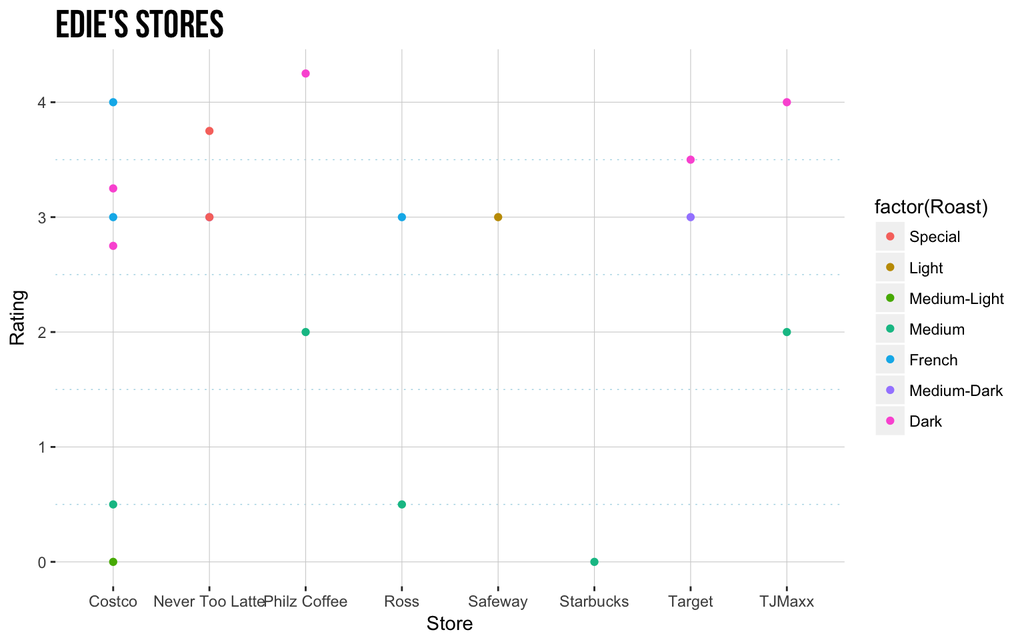

Apparently, my favorite store to buy coffee is Costco. I’m not surprised, and I’m glad my membership is doing me some good.

```
## This taster frequently goes to: Costco.
```

### Top 3 Coffees

Let’s look at my Top 3 Coffees over time. Here we see a plot of ratings over time just to examine what kind of bias I’m perpetuating as I rate the coffees I try.

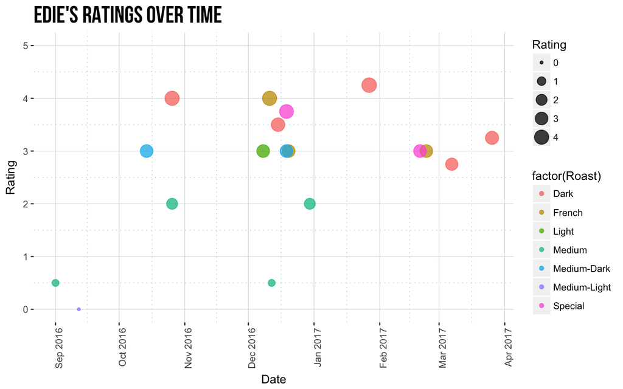

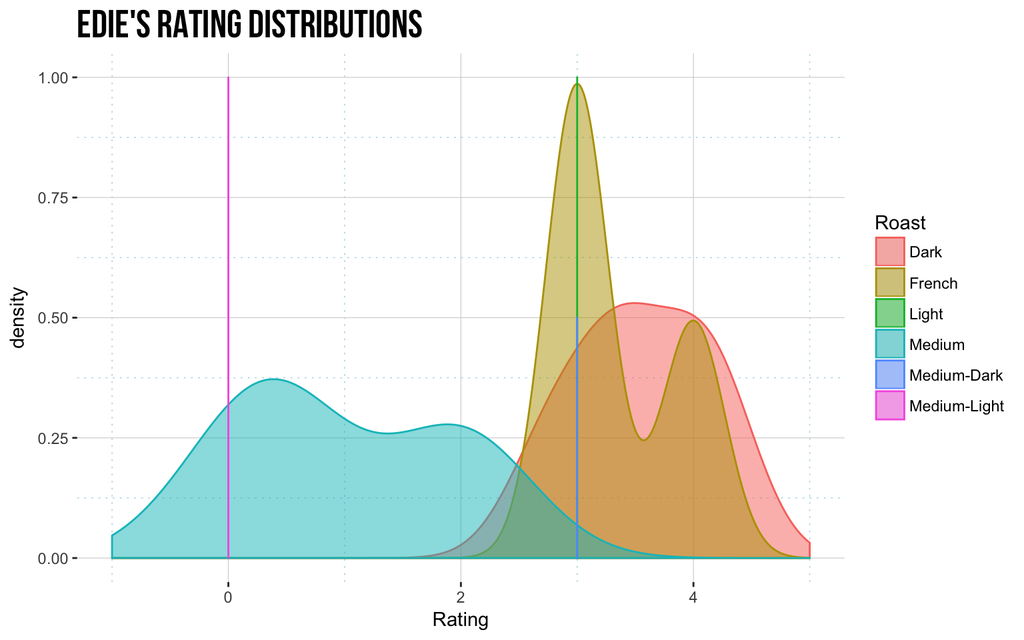

```
## This taster's average rating is: 2.552632.
```

```
## Including Special drinks, this taster's top 3 favorite drinks are:
##  Tantalizing Turkish.  French Roast OneCup.  Tall Dark and Handsome.
```

```
## Excluding special drinks, this taster's top 3 favorite drinks are:
##  Tantalizing Turkish.  French Roast OneCup.  Tall Dark and Handsome.
```